# index

Benjamin Keisling

1/17/2019

Load in libraries

Read in data from: Alaska Department of Fish and Game, Division of Commercial Fisheries. 2017. Daily salmon escapement counts from the OceanAK database, Alaska, 1921-2017. Knowledge Network for Biocomplexity. doi:10.5063/F1S46Q6M.

```
##        Location SASAP.Region sampleDate Species DailyCount  Method
## 1 Akalura Creek       Kodiak 1930-05-24 Sockeye          4 Unknown
## 2 Akalura Creek       Kodiak 1930-05-25 Sockeye         10 Unknown
## 3 Akalura Creek       Kodiak 1930-05-26 Sockeye          0 Unknown
## 4 Akalura Creek       Kodiak 1930-05-27 Sockeye          0 Unknown
## 5 Akalura Creek       Kodiak 1930-05-28 Sockeye          0 Unknown
## 6 Akalura Creek       Kodiak 1930-05-29 Sockeye          0 Unknown
##   Latitude Longitude Source
## 1  57.1641 -154.2287   ADFG
## 2  57.1641 -154.2287   ADFG
## 3  57.1641 -154.2287   ADFG
## 4  57.1641 -154.2287   ADFG
## 5  57.1641 -154.2287   ADFG
## 6  57.1641 -154.2287   ADFG
```

# Data Tidying

Calculate annual, regional, total escapement

- `separate` the data into year - month - day
- `group_by` `summarize` to calculate the sum over unique region-year-species combinations
- `filter` for salmon species

```
## # A tibble: 6 x 5
## # Groups:   year, SASAP.Region [4]
##    year SASAP.Region Species escapement n_obs
##   <dbl> <chr>        <chr>        <int> <int>
## 1  1921 Kodiak       Sockeye    1325061   143
## 2  1922 Chignik      Chinook        242    76
## 3  1922 Chignik      Sockeye     428977   134
## 4  1922 Kodiak       Sockeye     384683   156
## 5  1923 Chignik      Chinook        286    67
## 6  1923 Chignik      Sockeye     216124   101
```

Now we have the total count by year and region. Creating an interactive Data Table.

|  | year | SASAP.Region | Species | escapement | n_obs |
| --- | --- | --- | --- | --- | --- |
| 1 | 1921 | Kodiak | Sockeye | 1325061 | 143 |
| 2 | 1922 | Chignik | Chinook | 242 | 76 |
| 3 | 1922 | Chignik | Sockeye | 428977 | 134 |
| 4 | 1922 | Kodiak | Sockeye | 384683 | 156 |
| 5 | 1923 | Chignik | Chinook | 286 | 67 |
| 6 | 1923 | Chignik | Sockeye | 216124 | 101 |
| 7 | 1923 | Kodiak | Sockeye | 694580 | 145 |
| 8 | 1924 | Chignik | Chinook | 424 | 57 |
| 9 | 1924 | Chignik | Sockeye | 1010136 | 98 |
| 10 | 1924 | Kodiak | Sockeye | 775705 | 153 |

[output cut: 1474 more lines]

# Static Plots

Now were gonna make a plot. Note that in the AESTHETICS (aes) call, everything should refer to a column in your data.

RColorbrewer. tons of GGplot palettes.

timeseries of Kodiak escapement by species

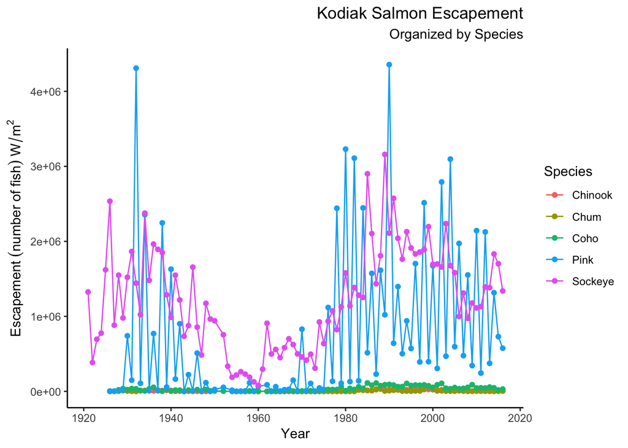

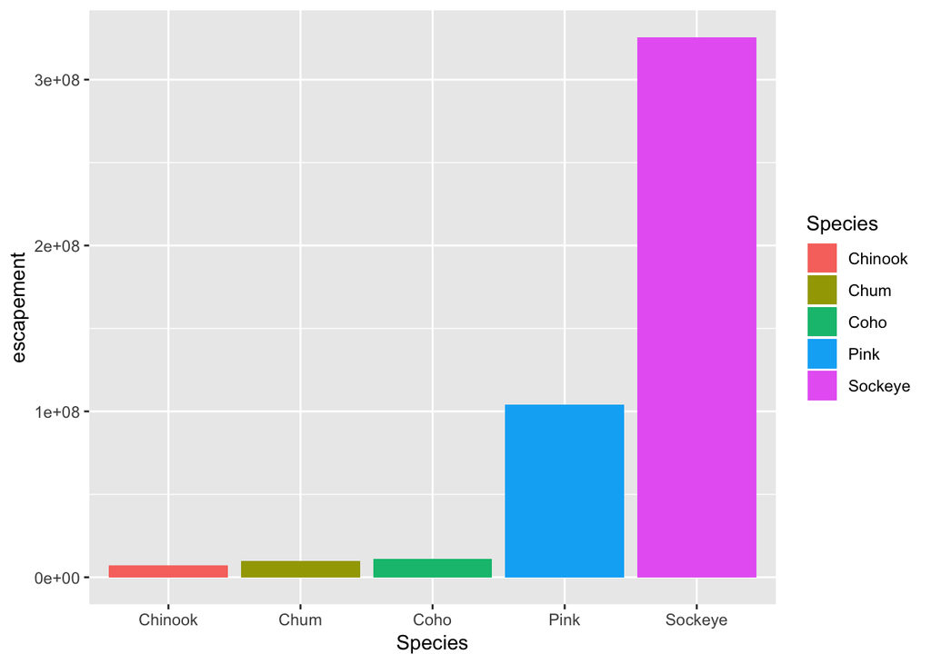

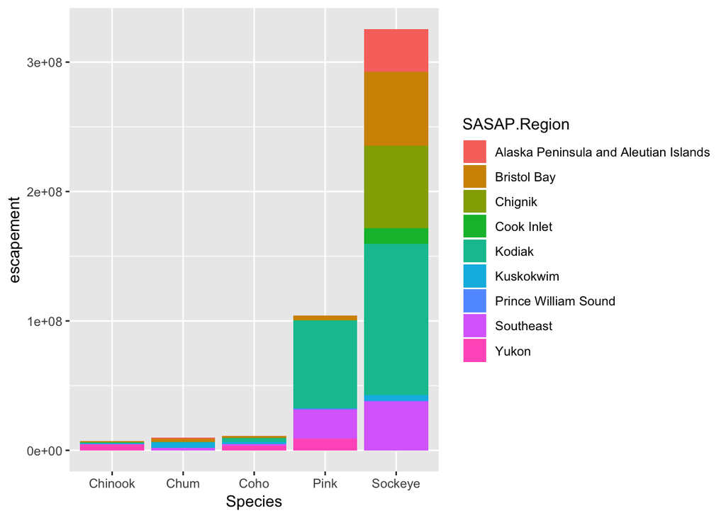

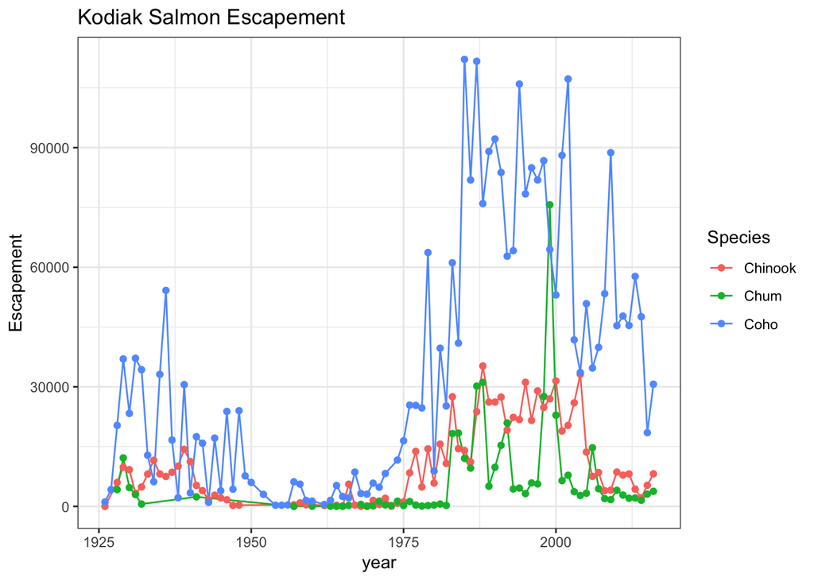

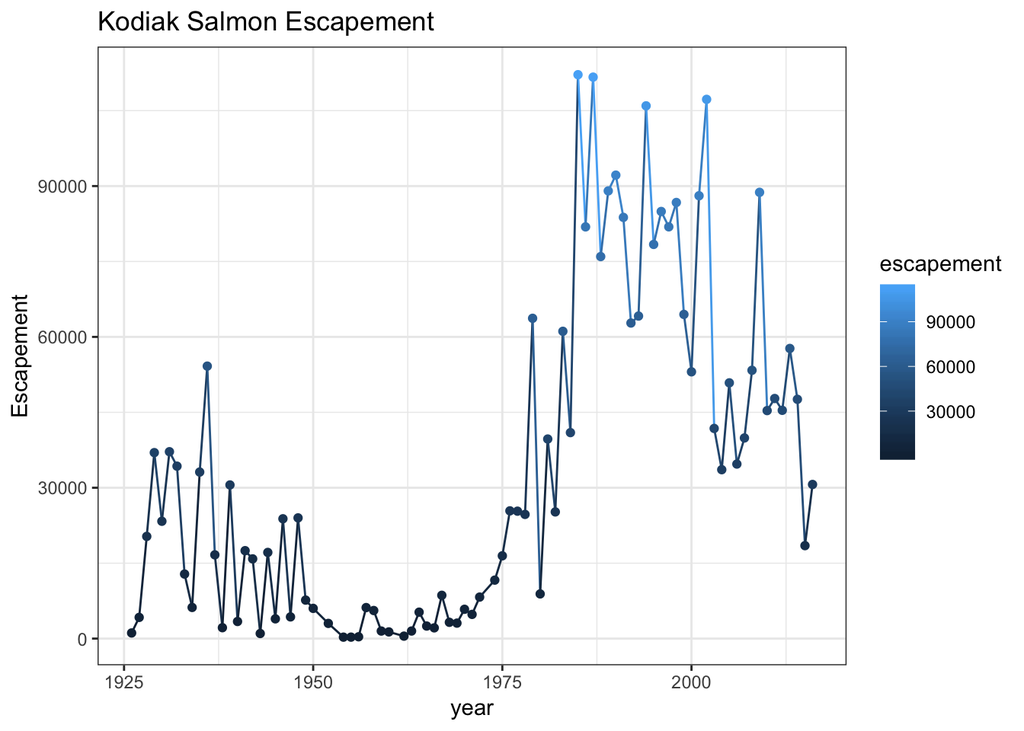

Plot timeseries of escapement by species for all regions

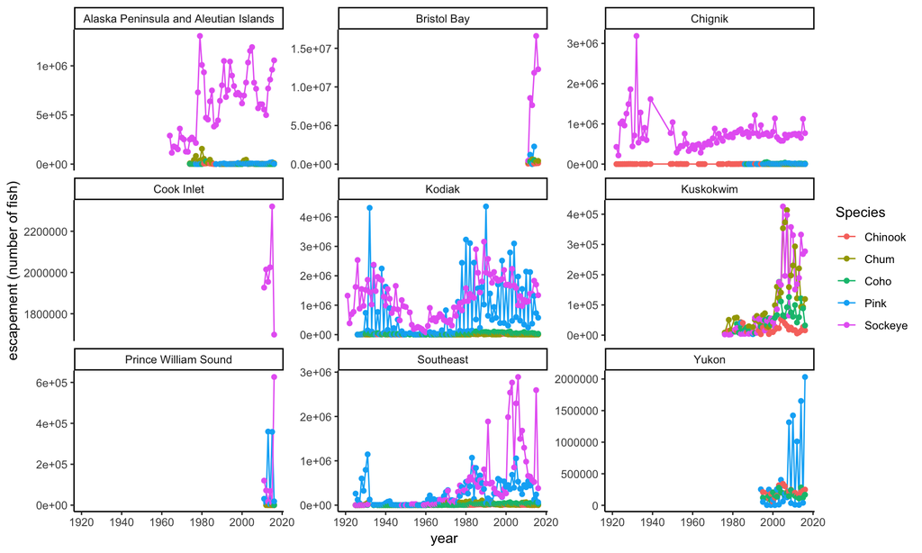

Now what if we want to save the data that we have cleaned up and modified?

# Interactive Map

Make a lap using leaflet

- find unique locations with lat/long values

|  | Location | Latitude | Longitude |
| --- | --- | --- | --- |
| 1 | Akalura Creek | 57.1641 | -154.2287 |
| 2 | Anvik River | 62.7 | -160.2 |
| 3 | Ayakulik River | 57.1956 | -154.529 |
| 4 | Bear Creek | 56.0389 | -160.2734 |
| 5 | Bear River | 56.0389 | -160.2734 |
| 6 | Big Bay Creek | 58.5426 | -152.5683 |
| 7 | Big Kitoi Creek | 58.1915 | -152.3754 |
| 8 | Black Lake | 56.392 | -158.937 |
| 9 | Buskin River | 57.7768 | -152.5372 |
| 10 | Chelatna Lake | 62.4731 | -151.4545 |

[output cut: 58 more lines]

Now that we have the locations we can create a leaflet map.

[interactive chart not shown]